# ISLR - Chapter 10

Unsupervised Learning

**Unsupervised Methods:**

- **Principal Components**
- **K-means Clustering**
- **Hierarchical Clustering**

#### **1. Principal Component Analysis**

We will use the USArrests data to illustrate the implementation of Principal Component method

```r
glimpse(USArrests)
```

```
Observations: 50
Variables: 4
$ Murder   <dbl> 13.2, 10.0, 8.1, 8.8, 9.0, 7.9, 3.3, 5.9, 15.4, 17.4, 5.3, 2.6, 10.4, 7.2, 2....
$ Assault  <int> 236, 263, 294, 190, 276, 204, 110, 238, 335, 211, 46, 120, 249, 113, 56, 115,...
$ UrbanPop <int> 58, 48, 80, 50, 91, 78, 77, 72, 80, 60, 83, 54, 83, 65, 57, 66, 52, 66, 51, 6...
$ Rape     <dbl> 21.2, 44.5, 31.0, 19.5, 40.6, 38.7, 11.1, 15.8, 31.9, 25.8, 20.2, 14.2, 24.0,...
```

We will now check for the means and variances of the variables and decide if standarization is required or not

```r
apply(USArrests, 2, var)
```

```
    Murder    Assault   UrbanPop       Rape
  18.97047 6945.16571  209.51878   87.72916
```

So, we will standardize the variables (i.e. bring the variance of all variables to 1 unit) before implementing the method.

This can be achieved by setting the `scale` argument of the `prcomp` function to **TRUE**

```r
pca_res
```

```
Standard deviations (1, .., p=4):
[1] 1.5748783 0.9948694 0.5971291 0.4164494

Rotation (n x k) = (4 x 4):
                PC1        PC2        PC3         PC4
Murder   -0.5358995  0.4181809 -0.3412327  0.64922780
Assault  -0.5831836  0.1879856 -0.2681484 -0.74340748
UrbanPop -0.2781909 -0.8728062 -0.3780158  0.13387773
Rape     -0.5434321 -0.1673186  0.8177779  0.08902432
```

The standard deviation displayed in the result is the standard deviation of each of the 4 principal components. (Remember that the total number of Principal Components for a dataset = MIN[n-1, p])

Notice that the standard deviations always decreases.

The **Rotation** in the above summary is nothing but the loadings.

The **first principal component** is loaded equally on all the 3 kinds of crime. And it has got a lower loading on `UrbanPop`

*So the first principal component esentially measure the average of the 3 crimes in any state*

The **second principal component** is heavily loaded on `UrbanPop`

**Visualizing the Principal Components**

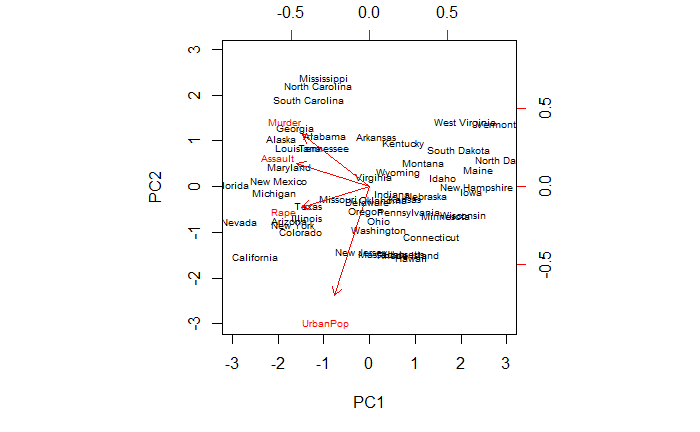

*Interpretation* Since the loadings were negative for the first principal component, states with a negative values have high crime rate (like Michigan, Nevada, California)

Similarly, the second principal component had a negative loading corresponding to UrbanPop. Hence states like New Jersey, Hawaii has high percentage of urban population.

#### **2. K-means clustering**

We will work with a simulated 2-dimensional data to illustrate the application of k-means clustering method.

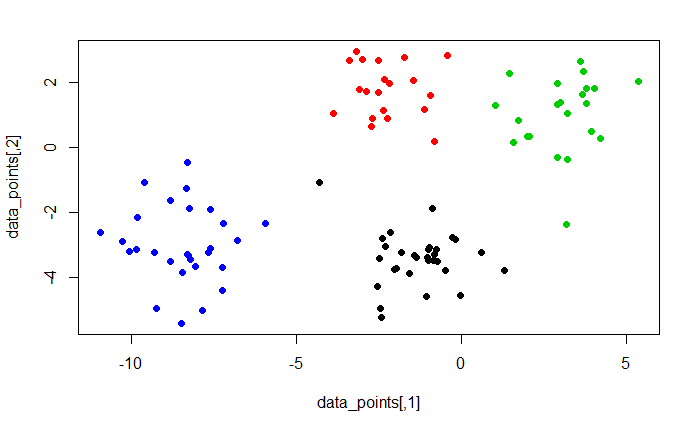

Now, the cluster_assign store the true cluster numbers for each data point.

We will now run k-means algorithm on this dataset. The true clsuter assignment will be hidden from the algorithm.

*Determining the optimal value of k -* * **Elbow Curve Method** *

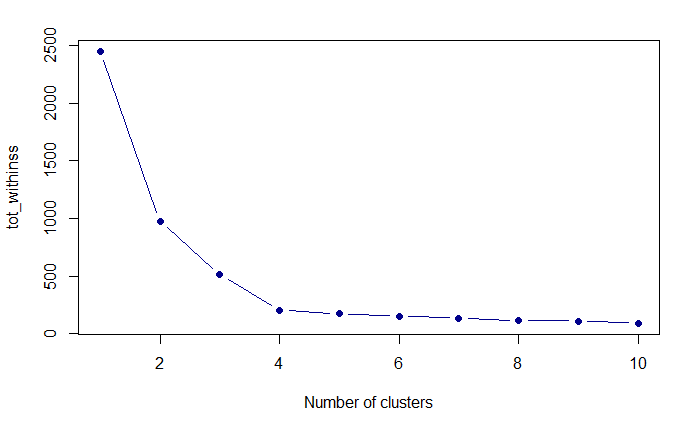

Based on the plot above, we will select k = 4

```r
kmeans_out
```

```
K-means clustering with 4 clusters of sizes 29, 22, 28, 21

Cluster means:
       [,1]      [,2]
1 -1.208942 -3.512880
2  3.062712  1.015205
3 -8.447148 -3.005280
4 -2.368405  1.643897

Clustering vector:
  [1] 1 4 2 3 3 1 4 4 3 4 3 2 3 2 3 2 2 4 1 1 2 3 3 1 3 3 2 3 1 1 4 1 3 3 2 1 2 3 1 2 3 1 1 2 2 4
 [47] 1 2 1 4 4 4 2 1 3 1 3 1 4 4 1 4 3 1 3 2 1 4 2 3 1 1 3 1 2 4 4 2 3 3 1 1 3 1 1 3 1 2 3 4 2 2
 [93] 2 1 4 3 4 4 4 3

Within cluster sum of squares by cluster:
[1] 40.73619 51.11144 72.60169 41.22388
 (between_SS / total_SS =  91.6 %)

Available components:

[1] "cluster"      "centers"      "totss"        "withinss"     "tot.withinss" "betweenss"
[7] "size"         "iter"         "ifault"
```

The output of k-means provides us with a number of metrics.

- - It displays the cluster centers
- - Cluster assignment for the input dataset
- - Within sum of squares for each cluster: smaller the value more homogeneous the cluster is

*Visualizing the output of k-means* We will compare the cluster results from k-means with the the true cluster assignments

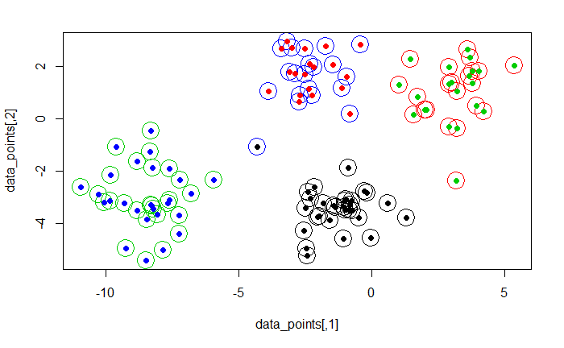

We can see that k-means did a pretty good job in correctly assigning points to the clusters.

#### **3. Hierarchical Clustering**

We will use the same simulated dataset used to perform k-means clustering.

We use the function `hclust()` that accepts 2 parameters, one is the `distance matrix` and the other is the linkage `method`.

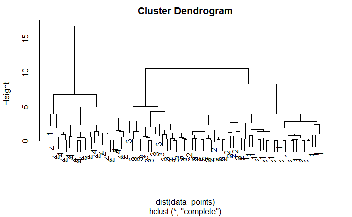

Recall that **complete** linkage uses the maximum pairwise-distance between points in 2 clusters.

We will now use other linkage methods:

- Single: minimum pairwise distance
- Average: Averages the pairwise-distances between 2 clsuters

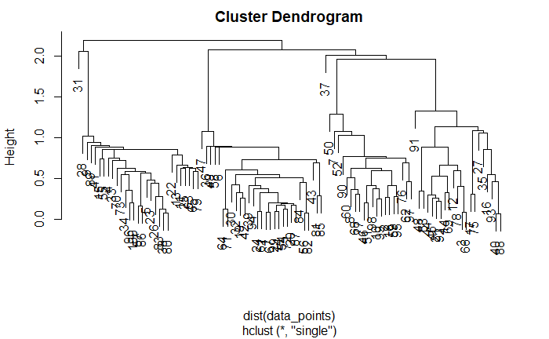

As expected, single linkage produced long, stringy trees. The 4 clsuters are not really prominent in the above dendogram.

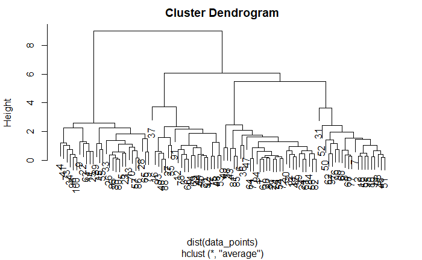

Average linkage, like complete method, produces balanced trees. The 4 clusters are quite visible from the above dendogram.

*Comparing the result from* `complete` *linkage method with the* **true clsuter** *assignments*

```r
table(hclust_complete_cut, cluster_assign)
```

```
                   cluster_assign
hclust_complete_cut  1  2  3  4
                  1 29  0  0  0
                  2  0 20  0  0
                  3  0  0 22  0
                  4  1  0  0 28
```

The table above shows that only 1 observation has been assigned to a wrong cluster.

*Comparing the result from* `complete` *linkage method with the* **k-means clsuter assignments**

```r
table(hclust_complete_cut, kmeans_out$cluster)
```

```
hclust_complete_cut  1  2  3  4
                  1 29  0  0  0
                  2  0  0  0 20
                  3  0 22  0  0
                  4  0  0 28  1
```